# Tutorial: tbl_regression

Last Updated: September 13, 2020

## Introduction

The [`tbl_regression()`](https://www.danieldsjoberg.com/gtsummary/reference/tbl_regression.html) function takes a **regression model object** in **R** and returns a **formatted table of regression model results** that is publication-ready. It is a simple way to summarize and present your analysis results using **R**! Like [`tbl_summary()`](https://www.danieldsjoberg.com/gtsummary/reference/tbl_summary.html), `tbl_regression()` creates highly customizable analytic tables with sensible defaults.

This vignette will walk a reader through the `tbl_regression()` function, and the various functions available to modify and make additions to an existing formatted regression table.

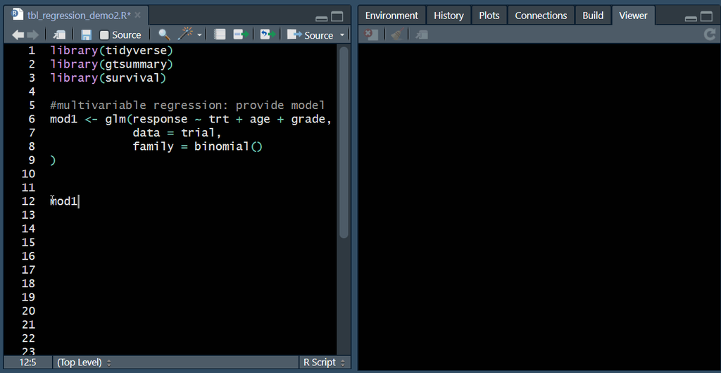

*Behind the scenes:* `tbl_regression()` uses `broom::tidy()` to perform the initial model formatting, and can accommodate many different model types (e.g. `lm()`, `glm()`, `survival::coxph()`, `survival::survreg()` and others are supported models known to work with {gtsummary}). It is also possible to specify your own function to tidy the model results if needed.

## Setup

Before going through the tutorial, install and load {gtsummary}.

```r
# install.packages("gtsummary")
library(gtsummary)
```

## Example data set

In this vignette we’ll be using the [**`trial`**](https://www.danieldsjoberg.com/gtsummary/reference/trial.html) data set which is included in the {gtsummary package}.

- This data set contains information from 200 patients who received one of two types of chemotherapy (Drug A or Drug B).
- The outcomes are tumor response and death.
- Each variable in the data frame has been assigned an **attribute label** (i.e. `attr(trial$trt, "label") == "Chemotherapy Treatment")` with the **[labelled](http://larmarange.github.io/labelled/)** package, which we highly recommend using. These labels are displayed in the {gtsummary} output table by default. Using {gtsummary} on a data frame without labels will simply print variable names, or there is an option to add labels later.

| Variable | Class | Label |
| --- | --- | --- |
| `trt` | character | Chemotherapy Treatment |
| `age` | numeric | Age |
| `marker` | numeric | Marker Level (ng/mL) |
| `stage` | factor | T Stage |
| `grade` | factor | Grade |
| `response` | integer | Tumor Response |
| `death` | integer | Patient Died |
| `ttdeath` | numeric | Months to Death/Censor |

Includes mix of continuous, dichotomous, and categorical variables

## Basic Usage

The default output from `tbl_regression()` is meant to be publication ready.

```r
# build logistic regression model
m1 <- glm(response ~ age + stage, trial, family = binomial)

# view raw model results
summary(m1)$coefficients
```

```
#>                Estimate Std. Error    z value   Pr(>|z|)
#> (Intercept) -1.48622424 0.62022844 -2.3962530 0.01656365
#> age          0.01939109 0.01146813  1.6908683 0.09086195
#> stageT2     -0.54142643 0.44000267 -1.2305071 0.21850725
#> stageT3     -0.05953479 0.45042027 -0.1321761 0.89484501
#> stageT4     -0.23108633 0.44822835 -0.5155549 0.60616530
```

- We will then a **regression model table** to summarize and present these results in just one line of code from {gtsummary}.

```r
tbl_regression(m1, exponentiate = TRUE)
```

| **Characteristic** | **OR**<sup>1</sup> | **95% CI**<sup>1</sup> | **p-value** |
| --- | --- | --- | --- |
| Age | 1.02 | 1.00, 1.04 | 0.091 |
| T Stage |  |  |  |
| T1 | — | — |  |
| T2 | 0.58 | 0.24, 1.37 | 0.2 |
| T3 | 0.94 | 0.39, 2.28 | 0.9 |
| T4 | 0.79 | 0.33, 1.90 | 0.6 |

<sup>1</sup> OR = Odds Ratio, CI = Confidence Interval

Note the sensible defaults with this basic usage (that can be customized later):

- The model was recognized as logistic regression with coefficients exponentiated, so the **header displayed “OR”** for odds ratio.
- **Variable types** are automatically detected and **reference rows** are added for categorical variables.
- **Model estimates** and **confidence intervals** are **rounded** and formatted.
- Because the variables in the data set were [labelled](http://larmarange.github.io/labelled/), the **labels were carried through** into the {gtsummary} output table. Had the data not been labelled, the default is to display the variable name.
- Variable levels are **indented** and **footnotes** added.

## Customize Output

There are four primary ways to customize the output of the regression model table.

1. Modify `tbl_regression()` function input arguments
2. Add additional data/information to a summary table with `add_*()` functions
3. Modify summary table appearance with the {gtsummary} functions
4. Modify table appearance with {gt} package functions

### Modifying function arguments

The `tbl_regression()` function includes many arguments for modifying the appearance.

| Argument | Description |
| --- | --- |
| `label=` | modify variable labels in table |
| `exponentiate=` | exponentiate model coefficients |
| `include=` | names of variables to include in output. Default is all variables |
| `show_single_row=` | By default, categorical variables are printed on multiple rows. If a variable is dichotomous and you wish to print the regression coefficient on a single row, include the variable name(s) here. |
| `conf.level=` | confidence level of confidence interval |
| `intercept=` | indicates whether to include the intercept |
| `estimate_fun=` | function to round and format coefficient estimates |
| `pvalue_fun=` | function to round and format p-values |
| `tidy_fun=` | function to specify/customize tidier function |

### {gtsummary} functions to add information

The {gtsummary} package has built-in functions for adding to results from `tbl_regression()`. The following functions add columns and/or information to the regression table.

| Function | Description |
| --- | --- |
| `add_global_p()` | adds the global p-value for a categorical variables |
| `add_glance_source_note()` | adds statistics from `broom::glance()` as source note |
| `add_vif()` | adds column of the variance inflation factors (VIF) |
| `add_q()` | add a column of q values to control for multiple comparisons |

### {gtsummary} functions to format table

The {gtsummary} package comes with functions specifically made to modify and format summary tables.

| Function | Description |
| --- | --- |
| `modify_header()` | update column headers |
| `modify_footnote()` | update column footnote |
| `modify_spanning_header()` | update spanning headers |
| `modify_caption()` | update table caption/title |
| `bold_labels()` | bold variable labels |
| `bold_levels()` | bold variable levels |
| `italicize_labels()` | italicize variable labels |
| `italicize_levels()` | italicize variable levels |
| `bold_p()` | bold significant p-values |

### {gt} functions to format table

The [{gt} package](https://gt.rstudio.com/index.html) is packed with many great functions for modifying table output—too many to list here. Review the package’s website for a full listing.

To use the {gt} package functions with {gtsummary} tables, the regression table must first be converted into a {gt} object. To this end, use the `as_gt()` function after modifications have been completed with {gtsummary} functions.

```r
m1 %>%
  tbl_regression(exponentiate = TRUE) %>%
  as_gt() %>%
  gt::tab_source_note(gt::md("*This data is simulated*"))
```

| **Characteristic** | **OR**<sup>1</sup> | **95% CI**<sup>1</sup> | **p-value** |
| --- | --- | --- | --- |
| Age | 1.02 | 1.00, 1.04 | 0.091 |
| T Stage |  |  |  |
| T1 | — | — |  |
| T2 | 0.58 | 0.24, 1.37 | 0.2 |
| T3 | 0.94 | 0.39, 2.28 | 0.9 |
| T4 | 0.79 | 0.33, 1.90 | 0.6 |

*This data is simulated*  
<sup>1</sup> OR = Odds Ratio, CI = Confidence Interval

### Example

There are formatting options available, such as adding bold and italics to text. In the example below,  
- Coefficients are **exponentiated** to give odds ratios  
- **Global p-values** for Stage are reported - Large p-values are rounded to **two decimal places**  
- P-values less than 0.10 are **bold** - Variable labels are **bold**  
- Variable levels are **italicized**

```r
# format results into data frame with global p-values
m1 %>%
  tbl_regression(
    exponentiate = TRUE,
    pvalue_fun = ~ style_pvalue(.x, digits = 2),
  ) %>%
  add_global_p() %>%
  bold_p(t = 0.10) %>%
  bold_labels() %>%
  italicize_levels()
```

| **Characteristic** | **OR**<sup>1</sup> | **95% CI**<sup>1</sup> | **p-value** |
| --- | --- | --- | --- |
| Age | 1.02 | 1.00, 1.04 | 0.087 |
| T Stage |  |  | 0.62 |
| T1 | — | — |  |
| T2 | 0.58 | 0.24, 1.37 |  |
| T3 | 0.94 | 0.39, 2.28 |  |
| T4 | 0.79 | 0.33, 1.90 |  |

<sup>1</sup> OR = Odds Ratio, CI = Confidence Interval

## Univariate Regression

The `tbl_uvregression()` function produces a table of univariate regression models. The function is a wrapper for `tbl_regression()`, and as a result, accepts nearly identical function arguments. The function’s results can be modified in similar ways to `tbl_regression()`.

```r
trial %>%
  select(response, age, grade) %>%
  tbl_uvregression(
    method = glm,
    y = response,
    method.args = list(family = binomial),
    exponentiate = TRUE,
    pvalue_fun = ~ style_pvalue(.x, digits = 2)
  ) %>%
  add_global_p() %>% # add global p-value
  add_nevent() %>% # add number of events of the outcome
  add_q() %>% # adjusts global p-values for multiple testing
  bold_p() %>% # bold p-values under a given threshold (default 0.05)
  bold_p(t = 0.10, q = TRUE) %>% # now bold q-values under the threshold of 0.10
  bold_labels()
```

```
#> add_q: Adjusting p-values with
#> `stats::p.adjust(x$table_body$p.value, method = "fdr")`
```

| **Characteristic** | **N** | **Event N** | **OR**<sup>1</sup> | **95% CI**<sup>1</sup> | **p-value** | **q-value**<sup>2</sup> |
| --- | --- | --- | --- | --- | --- | --- |
| Age | 183 | 58 | 1.02 | 1.00, 1.04 | 0.091 | 0.18 |
| Grade | 193 | 61 |  |  | 0.93 | 0.93 |
| I |  |  | — | — |  |  |
| II |  |  | 0.95 | 0.45, 2.00 |  |  |
| III |  |  | 1.10 | 0.52, 2.29 |  |  |

<sup>1</sup> OR = Odds Ratio, CI = Confidence Interval  
<sup>2</sup> False discovery rate correction for multiple testing

## Setting Default Options

The {gtsummary} regression functions and their related functions have sensible defaults for rounding and formatting results. If you, however, would like to change the defaults there are a few options. The default options can be changed using the {gtsummary} themes function `set_gtsummary_theme()`. The package includes pre-specified themes, and you can also create your own. Themes can control baseline behavior, for example, how p-values are rounded, coefficients are rounded, default headers, confidence levels, etc. For details on creating a theme and setting personal defaults, visit the [themes vignette](https://www.danieldsjoberg.com/gtsummary/articles/themes.html).

## Supported Models

Below is a listing of known and tested models supported by `tbl_regression()`. If a model follows a standard format and has a tidier, it’s likely to be supported as well, even if not listed below.

| Model | Details |
| --- | --- |
| `biglm::bigglm()` |  |
| `biglmm::bigglm()` |  |
| `brms::brm()` | `broom.mixed` package required |
| `cmprsk::crr()` | Limited support. It is recommended to use `tidycmprsk::crr()` instead. |
| `fixest::feglm()` | May fail with R <= 4.0. |
| `fixest::femlm()` | May fail with R <= 4.0. |
| `fixest::feNmlm()` | May fail with R <= 4.0. |
| `fixest::feols()` | May fail with R <= 4.0. |
| `gam::gam()` |  |
| `geepack::geeglm()` |  |
| `glmmTMB::glmmTMB()` | `broom.mixed` package required |
| `lavaan::lavaan()` | Limited support for categorical variables |
| `lfe::felm()` |  |
| `lme4::glmer.nb()` | `broom.mixed` package required |
| `lme4::glmer()` | `broom.mixed` package required |
| `lme4::lmer()` | `broom.mixed` package required |
| `logitr::logitr()` | Requires logitr >= 0.8.0 |
| `MASS::glm.nb()` |  |
| `MASS::polr()` |  |
| `mgcv::gam()` | Use default tidier `broom::tidy()` for smooth terms only, or `gtsummary::tidy_gam()` to include parametric terms |
| `mice::mira` | Limited support. If `mod` is a `mira` object, use `tidy_plus_plus(mod, tidy_fun = function(x, ...) mice::pool(x) %>% mice::tidy(...))` |
| `multgee::nomLORgee()` | Experimental support. Use `tidy_multgee()` as `tidy_fun`. |
| `multgee::ordLORgee()` | Experimental support. Use `tidy_multgee()` as `tidy_fun`. |
| `nnet::multinom()` |  |
| `ordinal::clm()` | Limited support for models with nominal predictors. |
| `ordinal::clmm()` | Limited support for models with nominal predictors. |
| `parsnip::model_fit` | Supported as long as the type of model and the engine is supported. |
| `plm::plm()` |  |
| `rstanarm::stan_glm()` | `broom.mixed` package required |
| `stats::aov()` | Reference rows are not relevant for such models. |
| `stats::glm()` |  |
| `stats::lm()` |  |
| `stats::nls()` | Limited support |
| `survey::svycoxph()` |  |
| `survey::svyglm()` |  |
| `survey::svyolr()` |  |
| `survival::clogit()` |  |
| `survival::coxph()` |  |
| `survival::survreg()` |  |
| `tidycmprsk::crr()` |  |
| `VGAM::vglm()` | Limited support. It is recommended to use `tidy_parameters()` as `tidy_fun`. |